# Trabajo de Investigacion

Celia Ruiz, Martin Heredia, Maria Emma Macedo, Luis Torres

5/12/2019

##Indice de Competitividad Global ¿Variables sociales pueden explicar la competitividad de los países?

#Traer las datas al R

####VARIABLE DEPENDIENTE

##GLOBAL COMPETITIVENESS INDEX

```r
library(htmltab)
link="https://github.com/MariaEmmaMacedov/Trabajo-final-Magallanes/raw/master/Global%20Competitiveness%20Report%20-%20Wikipedia.html"
GCR=htmltab(doc=link, which='//*[@id="mw-content-text"]/div/table[2]/tbody', encoding="UTF-8")
```

###VARIABLES INDEPENDIENTES

##UHC-UNIVERSAL HEALTH COVERAGE (COBERTURA DE SALUD)

```r
UHC=read.csv("https://github.com/MariaEmmaMacedov/Trabajo-final-Magallanes/raw/master/UHC.xlsx%20-%20Data.csv")
```

##GGG-GLOBAL GENDER GAP (BRECHA DE GENERO)

```r
GGG=read.csv("https://github.com/MariaEmmaMacedov/Trabajo-final-Magallanes/raw/master/GGG20152.xlsx%20-%20Hoja1.csv")
```

##IDH-INDICE DE DESARROLLO HUMANO

```r
library(htmltab)
link= "https://github.com/MariaEmmaMacedov/ClasesEstadistica/raw/master/_%20Human%20Development%20Reports.html"
idh = htmltab(doc = link, which ='/html/body/div[2]/div/section/div/div/div/div/div/table/tbody',encoding = "UTF-8")
```

```
## Neither <thead> nor <th> information found. Taking first table row for the header. If incorrect, specifiy header argument.
```

##EDUCACION INTERMEDIA

```r
library(rio)
EDUINTER="https://github.com/MartinHeredia16/Data-clases/blob/master/Educacion%20Intermedia.xls?raw=true"
DataEduInter=import(EDUINTER)
```

##TIC’S- TECNOLOGIA DE LA INFORMACION Y LA COMUNICACION

```r
library(rio)
Tics15="https://github.com/MartinHeredia16/Data-clases/blob/master/TICs.xlsx?raw=true"
DataTICS2015=import(Tics15)
```

##eco-dataeco

```r
lkCSV="https://docs.google.com/spreadsheets/d/e/2PACX-1vQhLhR6B_wu6M6ssIGm9fGkuitKE1MEoTSRAFy6tghDyTWSHzfj7SLw_vcrQLF2gA/pub?gid=1077831480&single=true&output=csv"
dataeco=read.csv(lkCSV)
```

```r
lkCSV="https://docs.google.com/spreadsheets/d/e/2PACX-1vQ8uUrENpRsfv0smfho7WX4SdcZs10SJC_M07RnpZ6NUhvfMsZe3qmLYZLTGlWcwQ/pub?gid=747425374&single=true&output=csv"
dataurb=read.csv(lkCSV)
```

```r
lkCSV="https://docs.google.com/spreadsheets/d/e/2PACX-1vTOgp0QD-YOBmRScKhNMYeLzYeLH5jbnFXEHLevscRF3umr_b0edtYgBwwlydAlEw/pub?gid=1044103274&single=true&output=csv"
dataserv=read.csv(lkCSV)
```

##LIMPIEZA DE DATOS

#Limpieza de Indice de competitividad global-GCR

```r
GCR$Rank=NULL
GCR$Country=trimws(GCR$Country,whitespace = "[\\h\\v]")
names(GCR)=c("Pais","Score GCR")
GCR$Pais=as.character(GCR$Pais)
GCR$`Score GCR`=as.numeric(GCR$`Score GCR`)
GCR$ISO=c("SGP","USA","HKG","NLD","CHE","JPN","DEU","SWE","GBR","DNK","FIN","TWN","KOR","CAN","FRA","AUS","NOR","LUX","NZL","ISR","AUT","BEL","ESP","IRL","ARE","ISL","MYS","CHN","QAT","ITA","EST","CZE","CHL","PRT","SVN","SAU","POL","MLT","LTU","THA","LVA","SVK","RUS","CYP","BHR","KWT","HUN","MEX","BGR","IDN","ROU","MUS","OMN","URY","KAZ","BRN","COL","AZE","GRC","ZAF","TUR","CRI","HRV","PHL","PER","PAN","VNM","IND","ARM","JOR","BRA","SRB","MNE","GEO","MAR","SYC","BRB","DOM","TTO","JAM","ALB","MKD","ARG","LKA","UKR","MDA","TUN","LBN","DZA","ECU","BWA","BIH","EGY","NAM","KEN","KGZ","PRY","GTM","IRN","RWA","HND","MNG","SLV","TJK","BGD","KHM","BOL","NEP","NIC","PAK","GHA","CPV","LAO","SEN","UGA","NGA","TZA","CIV","GAB","ZMB","SWZ","GIN","CMR","GMB","BEN","ETH","ZWE","MWI","MLI","BFA","LSO","MDG","VEN","MRT","BDI","AGO","MOZ","HTI","COD","YEM","TCD")
```

#Limpieza de UHC

```r
UHC$Series.Name=NULL
UHC$Series.Code=NULL
UHC$Country.Code=NULL
UHC$X1990..YR1990.=NULL
UHC$X2000..YR2000.=NULL
UHC$X2006..YR2006.=NULL
UHC$X2007..YR2007.=NULL
UHC$X2008..YR2008.=NULL
UHC$X2009..YR2009.=NULL
UHC$X2010..YR2010.=NULL
UHC$X2011..YR2011.=NULL
UHC$X2012..YR2012.=NULL
UHC$X2013..YR2013.=NULL
UHC$X2014..YR2014.=NULL
names(UHC)=c("Pais", "Indice UHC")
UHC$`Indice UHC`=gsub("\\..","",UHC$`Indice UHC`)
UHC$`Indice UHC`=as.numeric(UHC$`Indice UHC`)
UHC$Pais=as.character(UHC$Pais)
library(dplyr)
UHC[3,2]=76
UHC[7,2]=75
UHC[14,2]=72
UHC[15,2]=72
UHC[17,2]=79
UHC[20,2]=61
UHC[23,2]=59
UHC[29,2]=80
UHC[38,2]=33
UHC[44,2]=47
UHC[46,2]=38
UHC[50,2]=78
UHC[60,2]=77
UHC[61,2]=45
UHC[62,2]=38
UHC[69,2]=80
UHC[72,2]=46
UHC[79,2]=72
UHC[84,2]=68
UHC[85,2]=47
UHC[93,2]=63
UHC[103,2]=40
UHC[107,2]=77
UHC[114,2]=63
UHC[129,2]=60
UHC[136,2]=60
UHC[137,2]=59
UHC[140,2]=80
UHC[142,2]=80
UHC[153,2]=41
UHC[160,2]=77
UHC[164,2]=56
UHC[167,2]=68
UHC[170,2]=68
UHC[172,2]=80
UHC[176,2]=50
UHC[177,2]=22
UHC[179,2]=30
UHC[183,2]=69
UHC[185,2]=65
UHC[186,2]=43
UHC[187,2]=68
UHC[190,2]=60
UHC[196,2]=62
UHC[197,2]=75
UHC[200,2]=67
UHC[205,2]=63
UHC[209,2]=72
UHC[210,2]=56
UHC[211,2]=73
UHC[217,2]=55
UHC=UHC[-c(218:250),]
UHC=na.omit(UHC)
UHC$ISO=c("AFG","ALB","DZA","AGO","ATG","ARG","ARM","AUS","AUT","AZE","BHS","BHR","BGD","BRB","BLR","BEL","BLZ","BEN","BTN","BOL","BIH","BWA","BRA","BRN","BGR","BFA","BDI","CPV","KHM","CMR","CAN","CAF","TCD","CHL","CHN","COL","COM","COD","COG","CRI","CIV","HRV","CUB","CYP","CZE","DNK","DJI","DOM","ECU","EGY","SLV","GNQ","ERI","EST","SWZ","ETH","FJI","FIN","FRA","GAB","GMB","GEO","DEU","GHA","GRC","GRD","GTM","GIN","GUY","HTI","HND","HUN","ISL","IND","IDN","IRN","IRQ","IRL"," ISR","ITA","JAM","JPN","JOR","KAZ","KEN","KIR","KOR","KWT","KGZ","LAO","LVA","LBN","LSO","LBR","LBY","LTU","LUX","MDG","MWI","MYS","MDV","MLI","MLT","MRT","MUS","MEX","FSM","MDA","MNG","MNE","MAR","MOZ","MMR","NAM","NPL","NLD","NZL","NIC","NER","NER","MKD","NOR","OMN","PAK","PAN","PNG","PRY","PER","PHL","POL","PRT","QAT","ROU","RUS","RWA","WSM","STP","SAU","SEN","SRB","SYC","SLE","SGP","SVK","SVN","SLB","SOM","ZAF","SSD","ESP","LKA","LCA","VCT","SDN","SUR","SWE","CHE","SYR","TJK","TZA","THA","TLS","TGO","TON","TTO","TUN","TUR","TKM","UGA","UKR","ARE","GBR","USA","URY","UZB","VUT","VEN","VNM","YEM","ZMB","ZWE")
```

#Limpieza de Global gender gap-GGG

```r
library(tidyr)
##cambiamos nombres de variables
names(GGG)=c("Pais","index")
GGG=separate(GGG,index,into=c("delete1","globalindex","delete2","participacioneconomicayoportunidades","delete3","educacion","delete4","saludysupervivencia","delete5","empoderamientopolitico")," ")
##eliminamos las variables innecesarias
GGG=GGG[,-c(2,4,6,8,10,12)]
##colocamos la variable país como caracter
GGG$Pais=as.character(GGG$Pais)
str(GGG)
```

```
## 'data.frame':    145 obs. of  6 variables:
##  $ Pais                                : chr  "Iceland " "Norway" "Finland" "Sweden" ...
##  $ globalindex                         : chr  "0.881" "0.850" "0.850" "0.823" ...
##  $ participacioneconomicayoportunidades: chr  "0.836" "0.868" "0.815" "0.836" ...
##  $ educacion                           : chr  "1.000" "1.000" "1.000" "0.996" ...
##  $ saludysupervivencia                 : chr  "0.970" "0.974" "0.980" "0.974" ...
##  $ empoderamientopolitico              : chr  "0.719" "0.559" "0.607" "0.486" ...
```

```r
##colocamos las variables como numéricas
GGG[,c(2:6)]=lapply(GGG[,c(2:6)],as.numeric)
GGG=na.omit(GGG)
GGG$"ISO" = c("ISL", "NOR", "FIN", "SWE", "IRL", "RWA", "PHL", "CHE", "SVN", "NZL", "DEU", "NIC", "NLD", "DNK", "FRA", "NAM", "ZAF", "GBR", "BEL", "LVA", "EST", "BOL", "BDI", "BRB", "ESP", "MDA", "MOZ", "USA", "CUB", "CAN", "LTU", "LUX", "ECU", "BLR", "ARG", "AUS", "AUT", "CRI", "PRT", "BHS", "ITA", "COL", "BGR", "PAN", "SRB", "TTO", "KAZ", "KEN", "TZN", "CPV", "POL", "LAO", "ISR", "SGP", "BWA", "MNG", "ZWE", "UGA", "HRV", "THA", "LSO", "SLV", "GHA", "BGD", "JAM", "GUY", "UKR", "MWI", "MKD", "ALB", "MEX", "SEN", "CHL", "MDG", "RUS", "KGZ", "ROU", "VEN", "MNE", "HND", "CZE", "GEO", "VNM", "LKA", "BRA", "DOM", "GRC", "BRN", "PER", "CMR", "CHN", "IDN", "URY", "SUR", "TJK", "AZE", "SVK", "GMB", "HUN", "CYP", "JPN", "SWZ", "BLZ", "MLT", "ARM", "GTM", "PRY", "IND", "KHM", "NPL", "MYS", "LBR", "MDV", "BFA", "KOR", "ZMB", "KWT", "BTN", "ARE","MUS","FJI","QAT","BHR","ETH","NGA","AGO","TUN","DZA","BEN","TUR","GIN","MRT","CIV", "SAU", "OMN","EGY","MLI","LBN", "MAR","JOR","IRN","TCD","SYR","PAK","YEM")
```

#Limpieza de Indice de desarrollo humano-idh

```r
names(idh)=c("Puesto","Pais","PuntajeHDI","AñosVida","AñosEducacion","MedianaAñosEdu","PBI","PBImenosPuesto","Puesto2016")
idh=idh[-c(1),]
idh=idh[-c(60),]
row.names(idh)=NULL
idh=idh[-c(113,153,192:215),]
idh$PBI =   gsub("\\,", "", idh$PBI)
idh$PBImenosPuesto=NULL
idh$Puesto2016=NULL
idh$Puesto=NULL
idh$PBI = as.numeric(idh$PBI)
idh$MedianaAñosEdu = as.numeric(idh$MedianaAñosEdu)
idh$AñosEducacion = as.numeric(idh$AñosEducacion)
idh$AñosVida = as.numeric(idh$AñosVida)
idh$PuntajeHDI = as.numeric(idh$PuntajeHDI)
row.names(idh)=NULL
idh=na.omit(idh)
#colocamos codigo iso
idh$ISO=c("CHE","AUS","IRL","DEU","ISL","HKG","SWE","SGP","NLD","DNK","CAN","USA","GBR","FIN","NZL","BEL","LIE","JPN","AUT","LUX","ISR","KOR","FRA","SVN","ESP","CZE","ITA","MLT","EST","GRC","CYP","POL","ARE","AND","LTU","QAT","SVK","BRN","SAU","LVA","PRT","BHR","CHL","HUN","HRV","ARG","OMN","RUS","MNE","BGR","ROU","BLR","BHS","URY","KWT","MYS","BRB","KAZ","PLW","SYC","CRI","TUR","MUS","PAN","SRB","ALB","TTO","ATG","GEO","KNA","CUB","MEX","GRD","LKA","BIH","VEN","BRA","AZE","LBN","YUG","ARM","THA","DZA","CHN","ECU","UKR","PER","COL","LCA","FJI","MNG","DOM","JOR","TUN","JAM","TON","VCT","SUR","BWA","MDV","DMA","WSM","UZB","BLZ","MHL","LBY","TKM","GAB","PRY","MDA","ZAF","EGY","IDN","VNM","BOL","PSE","IRQ","SLV","KGZ","MAR","NIC","CPV","GUY","GTM","TJK","NAM","IND","FSM","TLS","HND","BHU","KIR","BGD","COG","VUT","LAO","GHA","GNQ","KEN","STP","SWZ","ZMB","KHM","AGO","MMR","NPL","PAK","CMR","PNG","TZA","SYR","ZWE","NGA","RWA","LSO","MRT","MDG","UGA","BEN","SEN","COM","TGO","SDN","AFG","HTI","CIV","MWI","DJI","ETH","GMB","GIN","COD","GNB","YEM","ERI","MOZ","LBR","MLI","BFA","SLE","BDI","TCD","SSD","CAF","NER")
```

Limpieza de Educacion intermedia-DataEduInter

```r
#transformamos a numericos ciertas variables
DataEduInter[,c(5:34)]=lapply(DataEduInter[,c(5:34)],as.numeric)
#cambiamos el nombre de country name a pais
names(DataEduInter)[1]= "Pais"
#borramos columnasque no nos sirven
DataEduInter[,c(3:50)]= NULL
DataEduInter[,(3:10)]= NULL
DataEduInter[,c(3,4,6,7)]= NULL
#limpiamos filas que no nos interesan como conjuntos de paises o algun otro parecido
DataEduInter=DataEduInter[-c(6,35,48,60,61,62,63,64,67,72,73,94,97,101,102,103,104,106,107,109,127,133,134,135,138,139,141,152,155,160,169,180,182,190,196,197,203,214,217,229,230,235,237,239,240,248,254,255,258),]
DataEduInter[1,3]=51.6
DataEduInter[4,3]=60.1
DataEduInter[3,3]=84.4
DataEduInter[7,3]=75.0
DataEduInter[8,3]=65.2
DataEduInter[12,3]=76.1
DataEduInter[15,3]=72.6
DataEduInter[17,3]=45.1
DataEduInter[18,3]=46
DataEduInter[30,3]=67.7
DataEduInter[31,3]=53.2
DataEduInter[32,3]=62.5
DataEduInter[31,3]=53.2
DataEduInter[41,3]=56.7
DataEduInter[31,3]=53.2
DataEduInter[42,3]=58.1
DataEduInter[46,3]=60.2
DataEduInter[49,3]=70.4
DataEduInter[51,3]=85.9
DataEduInter[71,3]=81.2
DataEduInter[78,3]=66.8
DataEduInter[82,3]=69.4
DataEduInter[85,3]=67.7
DataEduInter[93,3]=66.9
DataEduInter[108,3]=43.2
DataEduInter[112,3]=58.1
DataEduInter[121,3]=67
DataEduInter[123,3]=45.6
DataEduInter[128,3]=48
DataEduInter[147,3]=47.3
DataEduInter[150,3]=73.7
DataEduInter[159,3]=70.4
DataEduInter[164,3]=64.3
DataEduInter[165,3]=38.5
DataEduInter[172,3]=41.8
DataEduInter[174,3]=67.3
DataEduInter[177,3]=43.5
DataEduInter[178,3]=73.8
DataEduInter[179,3]=53.7
DataEduInter[183,3]=47.3
DataEduInter[187,3]=65.3
DataEduInter[199,3]=83.9
DataEduInter[202,3]=47.9
DataEduInter[205,3]=41.8
DataEduInter[206,3]=34.7
DataEduInter[208,3]=91.7
DataEduInter[209,3]=44.6
DataEduInter[219,3]=72.2
DataEduInter[231,3]=75.1
DataEduInter[238,3]=52.8
DataEduInter[245,3]=80.9
DataEduInter[246,3]=62.9
DataEduInter[253,3]=63.0
DataEduInter[259,3]=46.4
DataEduInter[261,3]=55.0
DataEduInter[263,3]=44.4
DataEduInter[264,3]=65.8
row.names(DataEduInter)=NULL
DataEduInter[180,3]=72.2
DataEduInter[190,3]=75.1
DataEduInter[195,3]=52.8
DataEduInter[200,3]=80.9
DataEduInter[201,3]=62.9
DataEduInter[207,3]=63
DataEduInter[210,3]=46.4
DataEduInter[212,3]=55
DataEduInter[214,3]=44.4
DataEduInter[215,3]=65.8
DataEduInter=DataEduInter[c(1:215),]
DataEduInter=na.omit(DataEduInter)
names(DataEduInter)[2]="ISO"
```

##LIMPIEZA DE DATOS URBANIZACION

```r
dataeco <- na.omit(dataeco)
dataserv <- na.omit(dataserv)
dataurb <- na.omit(dataurb)
dataeco$Series.Name=NULL
dataeco$Series.Code=NULL
dataeco$Country.Name=NULL
dataserv$Series.Name=NULL
dataserv$Series.Code=NULL
dataserv$Country.Name=NULL
dataurb$Series.Name=NULL
dataurb$Series.Code=NULL
dataurb$Country.Name=NULL
names (dataeco)[2] = "ECO16"
names (dataserv)[2] = "SER16"
names (dataurb)[2] = "URB16"
names(dataeco)[1]="ISO"
names(dataserv)[1]="ISO"
names(dataurb)[1]="ISO"
```

#Creacion indice de Urbanizacion

```r
data1=merge(dataeco, dataserv, by.x = "ISO", by.y = "ISO")
IND1=merge(data1, dataurb, by.x = "ISO", by.y =  "ISO")
```

#Analisis Factorial

```r
Correla=IND1[,-c(1)]
library(polycor)
CorCor=polycor::hetcor(Correla)$correlations
```

```r
str(IND1)
```

```
## 'data.frame':    191 obs. of  4 variables:
##  $ ISO  : Factor w/ 218 levels "","ABW","AFG",..: 2 3 4 5 7 8 9 11 12 13 ...
##  $ ECO16: num  69.1 53.2 50.7 68.7 84.6 64.1 68.8 69.2 65.9 66.9 ...
##  $ SER16: num  43.2 25 64.1 58.4 86 91.6 63.1 24.8 85.8 57.9 ...
##  $ URB16: num  97.5 42.1 48.6 97.7 98.6 94.3 93.4 87.5 100 100 ...
```

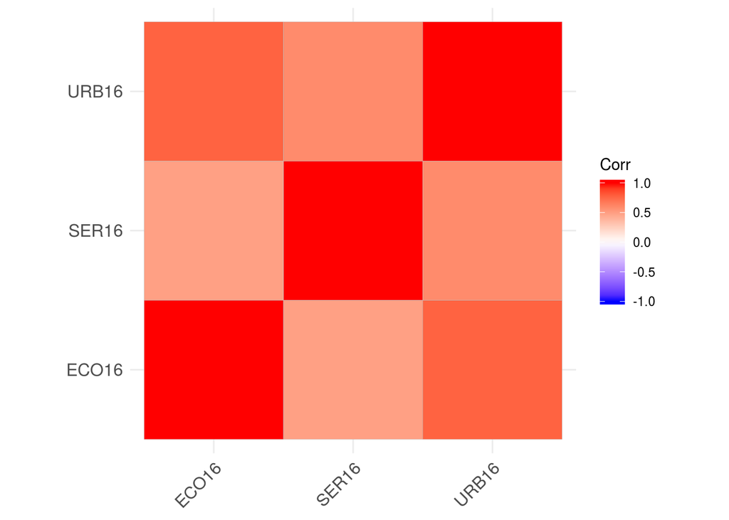

```r
library(ggcorrplot)
ggcorrplot(CorCor)
```

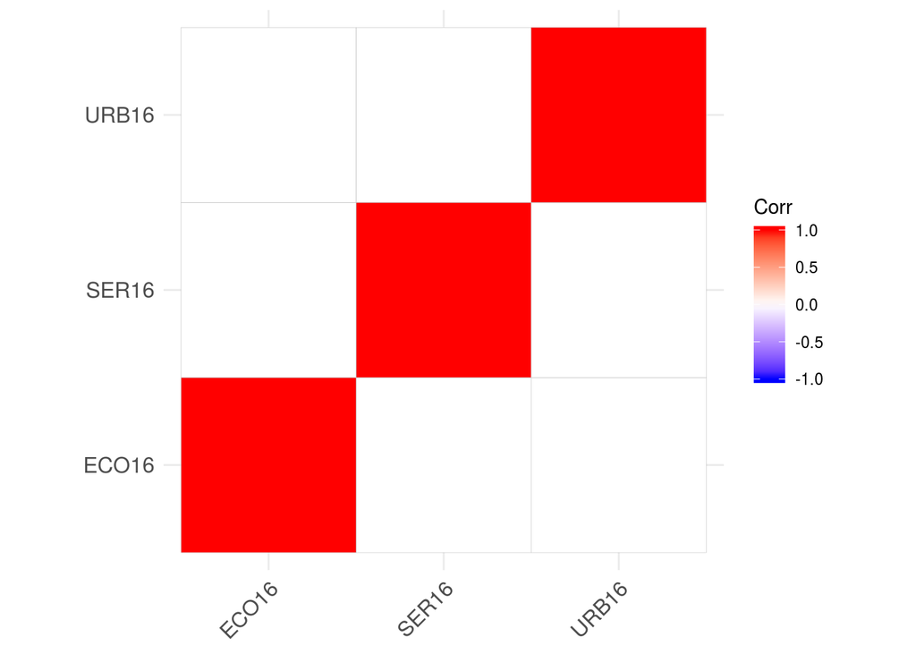

```r
ggcorrplot(CorCor,
          p.mat = cor_pmat(CorCor),
          insig = "blank")
```

```r
library(psych)
psych::KMO(CorCor)
```

```
## Kaiser-Meyer-Olkin factor adequacy
## Call: psych::KMO(r = CorCor)
## Overall MSA =  0.65
## MSA for each item =
## ECO16 SER16 URB16
##  0.64  0.80  0.60
```

```r
cortest.bartlett(CorCor,n=nrow(Correla))$p.value>0.05
```

```
## [1] FALSE
```

```r
library(matrixcalc)

is.singular.matrix(CorCor)
```

```
## [1] FALSE
```

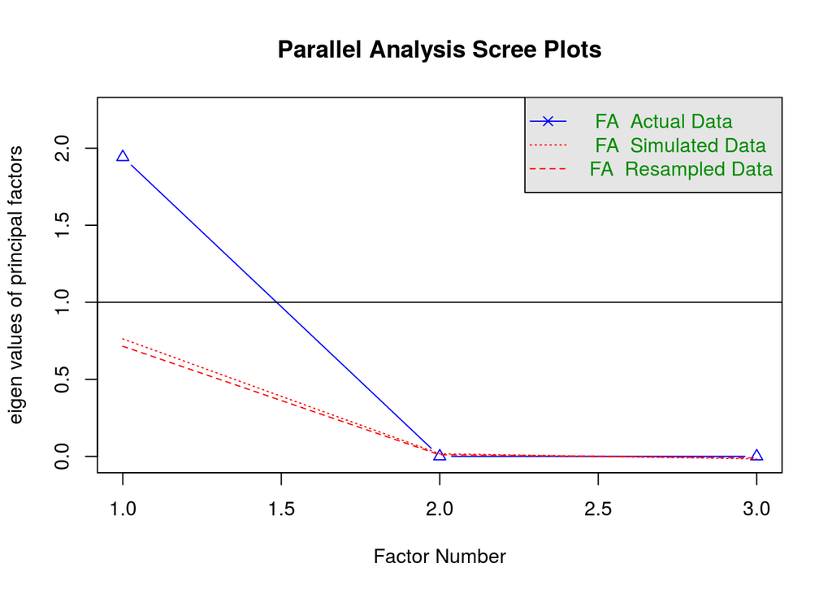

```
## Parallel analysis suggests that the number of factors =  1  and the number of components =  NA
```

```r
fa.parallel(Correla,fm = 'ML', fa = 'fa')
```

```r
library(GPArotation)
luna <- fa(Correla,nfactors = 1,cor = 'mixed',rotate = "varimax",fm="minres")
```

```
##
## mixed.cor is deprecated, please use mixedCor.
```

```r
print(luna$loadings)
```

```
##
## Loadings:
##       MR1
## ECO16 0.802
## SER16 0.608
## URB16 0.964
##
##                  MR1
## SS loadings    1.942
## Proportion Var 0.647
```

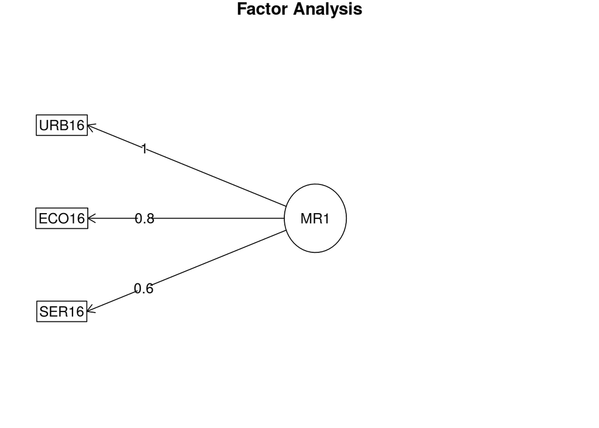

```r
fa.diagram(luna)
```

```r
luna$crms
```

```
## [1] NA
```

```r
luna$RMSEA
```

[output not shown]

```r
luna$TLI
```

```
## [1] -Inf
```

```r
sort(luna$communality)
```

```
##     SER16     ECO16     URB16
## 0.3692894 0.6438519 0.9293215
```

```r
str(IND1)
```

```
## 'data.frame':    191 obs. of  4 variables:
##  $ ISO  : Factor w/ 218 levels "","ABW","AFG",..: 2 3 4 5 7 8 9 11 12 13 ...
##  $ ECO16: num  69.1 53.2 50.7 68.7 84.6 64.1 68.8 69.2 65.9 66.9 ...
##  $ SER16: num  43.2 25 64.1 58.4 86 91.6 63.1 24.8 85.8 57.9 ...
##  $ URB16: num  97.5 42.1 48.6 97.7 98.6 94.3 93.4 87.5 100 100 ...
```

```r
IND01=IND1[,2:4]/100
```

```r
IND1$INDECO[IND01$ECO16<0.200]="1"
IND1$INDECO[IND01$ECO16>=0.200 & IND01$ECO16<0.400]="2"
IND1$INDECO[IND01$ECO16>=0.400 & IND01$ECO16<0.600]="3"
IND1$INDECO[IND01$ECO16>=0.600 & IND01$ECO16<0.800]="4"
IND1$INDECO[IND01$ECO16>=0.800]="5"
```

```r
IND1$INDSER[IND01$SER16<0.200]="1"
IND1$INDSER[IND01$SER16>=0.200 & IND01$SER16<0.400]="2"
IND1$INDSER[IND01$SER16>=0.400 & IND01$SER16<0.600]="3"
IND1$INDSER[IND01$SER16>=0.600 & IND01$SER16<0.800]="4"
IND1$INDSER[IND01$SER16>=0.800]="5"
```

```r
IND1$INDURB[IND01$URB16<0.200]="1"
IND1$INDURB[IND01$URB16>=0.200 & IND01$URB16<0.400]="2"
IND1$INDURB[IND01$URB16>=0.400 & IND01$URB16<0.600]="3"
IND1$INDURB[IND01$URB16>=0.600 & IND01$URB16<0.800]="4"
IND1$INDURB[IND01$URB16>=0.800]="5"
```

```r
IND1[,5:7]=lapply(IND1[,5:7], as.numeric)
```

```r
str(IND1)
```

```
## 'data.frame':    191 obs. of  7 variables:
##  $ ISO   : Factor w/ 218 levels "","ABW","AFG",..: 2 3 4 5 7 8 9 11 12 13 ...
##  $ ECO16 : num  69.1 53.2 50.7 68.7 84.6 64.1 68.8 69.2 65.9 66.9 ...
##  $ SER16 : num  43.2 25 64.1 58.4 86 91.6 63.1 24.8 85.8 57.9 ...
##  $ URB16 : num  97.5 42.1 48.6 97.7 98.6 94.3 93.4 87.5 100 100 ...
##  $ INDECO: num  4 3 3 4 5 4 4 4 4 4 ...
##  $ INDSER: num  3 2 4 3 5 5 4 2 5 3 ...
##  $ INDURB: num  5 3 3 5 5 5 5 5 5 5 ...
```

```r
IND1$sumaparcial = rowSums (IND1[ , 5:7])
```

```r
IND1[,9]=IND1[,8]/3
```

```r
MEPO=data.frame(IND1$ISO, IND1$V9)
```

```r
names(MEPO)[1]= "ISO"
names(MEPO)[2]= "INDMEP"
```

##MERGE

```r
total1=merge(UHC,GGG, by.x = "ISO", by.y= "ISO")
```

```r
total1$Pais.x=NULL
total1$Pais.y=NULL
```

```r
total2=merge(total1, GCR, by.x ="ISO", by.y ="ISO")
```

```r
total3=merge(total2,idh, by.x="ISO", by.y="ISO")
```

```r
total4=merge(total3,DataTICS2015, by.x="ISO", by.y="ISO")
```

```r
total5=merge(total4, DataEduInter, by.x="ISO", by.y="ISO")
```

```r
total5$Pais.x=NULL
total5$Pais.y=NULL
total5$Country=NULL
```

```r
names(total5)[16]="PEA intermedia"
```

```r
total6=merge(total5,dataeco,by.x = "ISO",by.y = "ISO")
total7=merge(total6,dataserv, by.x="ISO", by.y="ISO")
total8=merge(total7,dataurb,by.x="ISO", by.y="ISO")
```

```r
row.names(total8)=total8$Pais
total8$Pais=NULL
```

```r
total9=merge(total8,MEPO, by.x="ISO", by.y="ISO")
```

##CLUSTERING

```r
library(stringr)
library(magrittr)
library(htmltab)
library(factoextra)
library(cluster)
set.seed(2019)
library(cluster)
total9clust=total9[,-c(1,3,8,9,13,15,20)]
g.dist9 = daisy(total9clust, metric="gower") #calculando la distancia
```

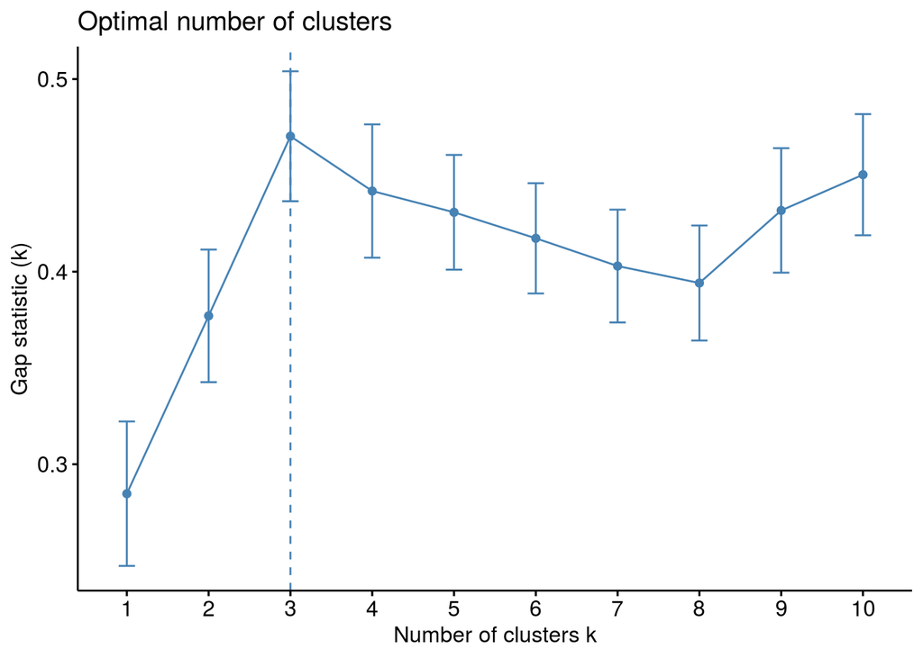

```r
#particion
fviz_nbclust(total9clust, pam,diss=g.dist9,method = "gap_stat",k.max = 10,verbose = F)
```

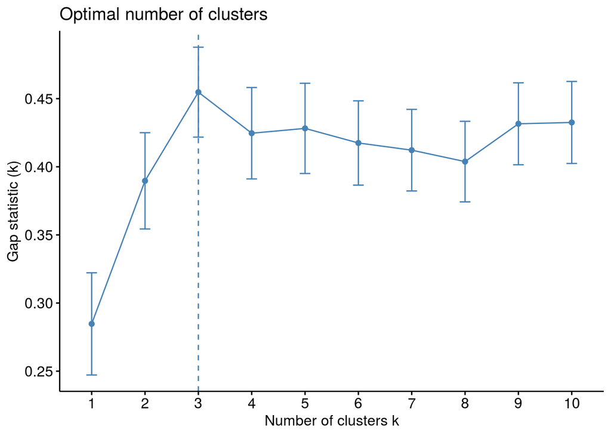

```r
#jerarquizacion
fviz_nbclust(total9clust, hcut,diss=g.dist9,method = "gap_stat",k.max = 10,verbose = F)
```

```r
#la sugerencia es de 3 clusters
res.pam9 = pam(g.dist9,3,cluster.only = F)
res.agnes9 = hcut(g.dist9, k = 3,hc_func='agnes',hc_method = "ward.D")
res.diana9 = hcut(g.dist9, k = 3,hc_func='diana')
```

```
##   cluster size ave.sil.width
## 1       1   16          0.41
## 2       2   48          0.22
## 3       3   22          0.44
```

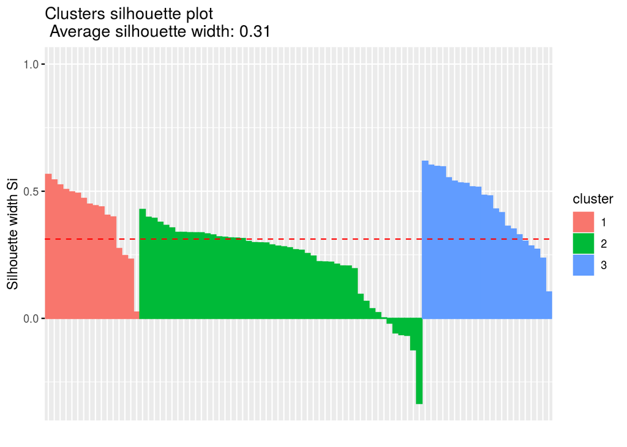

```r
fviz_silhouette(res.pam9)
```

```
##   cluster size ave.sil.width
## 1       1   16          0.41
## 2       2   50          0.20
## 3       3   20          0.48
```

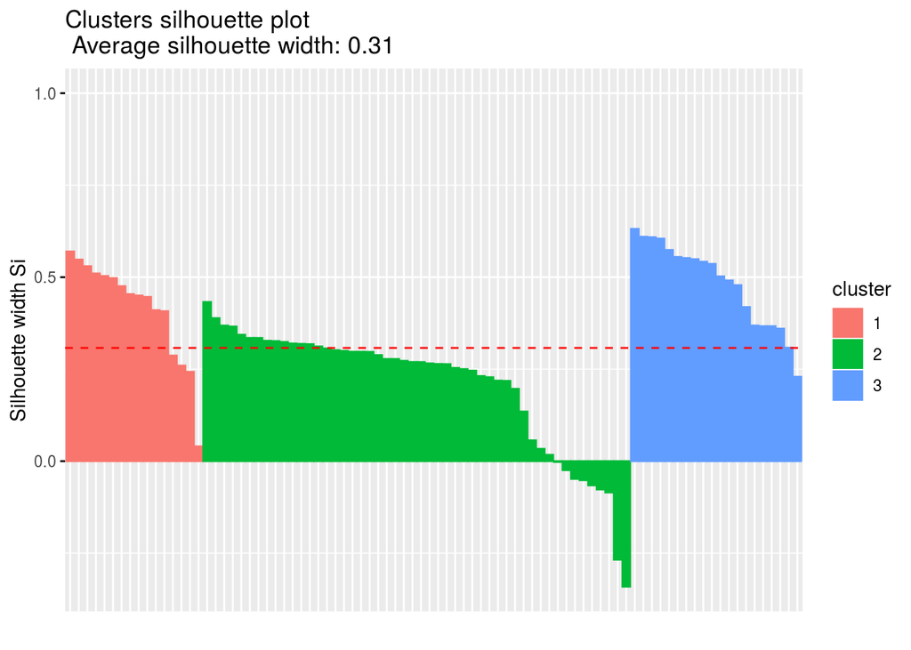

```r
fviz_silhouette(res.agnes9)
```